[figure not shown]

# The Thematic map

Last session we created a file with several layers:

```python
import geopandas as gpd

linkGit='https://github.com/rodrigosalazarl-GH/Mapas_Tematicos/raw/main/'
linkWorldMaps='Mundo/worldMaps.gpkg'
```

Llamo a la librería de geopandas como gpd y asigno variables para ubicar el archivo (**worldMaps.gpkg**)

```python
gpd.list_layers(linkGit+linkWorldMaps)
```

|  | name | geometry_type |
| --- | --- | --- |
| 0 | rivers | MultiLineString |
| 1 | cities | Point |
| 2 | countries | MultiPolygon |

El comando gpd.list_layers() es útil para saber las capas que contiene el archivo, para la tarea solo utilizaré la capa *countries*

```python
countries=gpd.read_file(linkGit+linkWorldMaps,layer='countries')

# see some
countries
```

|  | COUNTRY | geometry |
| --- | --- | --- |
| 0 | Aruba (Netherlands) | MULTIPOLYGON (((-69.88223 12.41111, -69.94695 ... |
| 1 | Antigua and Barbuda | MULTIPOLYGON (((-61.73889 17.54055, -61.75195 ... |
| 2 | Afghanistan | MULTIPOLYGON (((61.27656 35.60725, 61.29638 35... |
| 3 | Algeria | MULTIPOLYGON (((-5.15213 30.18047, -5.13917 30... |
| 4 | Azerbaijan | MULTIPOLYGON (((46.54037 38.87559, 46.49554 38... |
| ... | ... | ... |
| 247 | South Sudan | MULTIPOLYGON (((34.21807 9.96458, 34.20722 9.9... |
| 248 | Indonesia | MULTIPOLYGON (((123.21846 -10.80917, 123.19832... |
| 249 | East Timor | MULTIPOLYGON (((124.41824 -9.3001, 124.40446 -... |
| 250 | Curacao (Netherlands) | MULTIPOLYGON (((-68.96556 12.19889, -68.91196 ... |
| 251 | Bonaire (Netherlands) | MULTIPOLYGON (((-68.19736 12.22264, -68.19292 ... |

252 rows × 2 columns

Guardo la capa countries del archivo gpkg en la variable (countries) usando gpd.read_file(), y compruebo usando (countries) si el tipo de dato es correcto y no hay errores en la columna geometry

```python
import pandas as pd

someDataLink='Mundo/some_dataworld.csv'

someData=pd.read_csv(linkGit+someDataLink)

## data available
someData.info()
```

```
<class 'pandas.core.frame.DataFrame'>
RangeIndex: 172 entries, 0 to 171
Data columns (total 10 columns):
 #   Column        Non-Null Count  Dtype
---  ------        --------------  -----
 0   Country       172 non-null    object
 1   iso2          171 non-null    object
 2   iso3          172 non-null    object
 3   region        172 non-null    object
 4   fragility     172 non-null    float64
 5   co2           172 non-null    int64
 6   sq_km         172 non-null    int64
 7   num_airports  172 non-null    int64
 8   population    172 non-null    int64
 9   mobiles       172 non-null    int64
dtypes: float64(1), int64(5), object(4)
memory usage: 13.6+ KB
```

someData=pd.read_csv(linkGit+someDataLink) carga los datos del csv y guarda en la variable someData. someData.info() muestra la estructura de los datos

## Pre Processing: Merging

```python
someData.head()
```

|  | Country | iso2 | iso3 | region | fragility | co2 | sq_km | num_airports | population | mobiles |
| --- | --- | --- | --- | --- | --- | --- | --- | --- | --- | --- |
| 0 | AFGHANISTAN | AF | AFG | SOUTH ASIA | 105.0 | 7893000 | 652230 | 68 | 40121552 | 23000000 |
| 1 | ALBANIA | AL | ALB | EUROPE | 58.9 | 3794000 | 28748 | 3 | 3107100 | 2610000 |
| 2 | ALGERIA | DZ | DZA | AFRICA | 75.4 | 151633000 | 2381740 | 95 | 47022473 | 51500000 |
| 3 | ANGOLA | AO | AGO | AFRICA | 87.8 | 19362000 | 1246700 | 107 | 37202061 | 25700000 |
| 4 | ANTIGUA AND BARBUDA | AG | ATG | CENTRAL AMERICA AND THE CARIBBEAN | 54.4 | 729000 | 443 | 4 | 102634 | 184000 |

someData.head() me muestra los datos disponibles para los primeros paises y la columna Country, compruebo si tengo los datos que voy a utilizar: region y mobiles

### Geo Merging

```python
countries.COUNTRY.head()
```

|  | COUNTRY |
| --- | --- |
| 0 | Aruba (Netherlands) |
| 1 | Antigua and Barbuda |
| 2 | Afghanistan |
| 3 | Algeria |
| 4 | Azerbaijan |

**dtype:** object

```python
someData.Country.head()
```

|  | Country |
| --- | --- |
| 0 | AFGHANISTAN |
| 1 | ALBANIA |
| 2 | ALGERIA |
| 3 | ANGOLA |
| 4 | ANTIGUA AND BARBUDA |

**dtype:** object

Los dos comandos anteriores muestran que los nombres de los paises no están escritos de la misma manera en el gpd y en el df

```python
countries.rename(columns={'COUNTRY':'Country'},inplace=True)
```

El comando countries.rename() cambia el nombre de la columna para que coincida con la otra data. Este es el primer paso del Geo Merging.

```python
countries['Country']=countries.Country.str.upper()
```

El comando countries.Country.str.upper() cambia las letras de la columna countries a mayusculas

```python
onlyDF=set(someData.Country)- set(countries.Country)
onlyGDF=set(countries.Country)- set(someData.Country)
```

Las dos líneas de código anteriores sirven para identificar diferencias en los nombres de países antes de unir las tablas:

```python
onlyDF
```

```
{'BAHAMAS (THE)',
 'BOLIVIA (PLURINATIONAL STATE OF)',
 'BRUNEI DARUSSALAM',
 'CABO VERDE',
 'CENTRAL AFRICAN REPUBLIC (THE)',
 'COMOROS (THE)',
 'CONGO (THE DEMOCRATIC REPUBLIC OF THE)',
 'CONGO (THE)',
 "CÔTE D'IVOIRE",
 'DOMINICAN REPUBLIC (THE)',
 'ESWATINI',
 'GAMBIA (THE)',
 'IRAN (ISLAMIC REPUBLIC OF)',
 'KOREA (THE REPUBLIC OF)',
 "LAO PEOPLE'S DEMOCRATIC REPUBLIC (THE)",
 'MICRONESIA (FEDERATED STATES OF)',
 'MOLDOVA (THE REPUBLIC OF)',
 'NETHERLANDS (THE)',
 'NIGER (THE)',
 'NORTH MACEDONIA',
 'NORTHERN MARIANA ISLANDS (THE)',
 'PHILIPPINES (THE)',
 'RUSSIAN FEDERATION (THE)',
 'SAMOA',
 'SUDAN (THE)',
 'TANZANIA, THE UNITED REPUBLIC OF',
 'TIMOR-LESTE',
 'UNITED ARAB EMIRATES (THE)',
 'UNITED KINGDOM OF GREAT BRITAIN AND NORTHERN IRELAND (THE)',
 'UNITED STATES OF AMERICA (THE)'}
```

```python
onlyGDF
```

```
{'AMERICAN SAMOA (US)',
 'AMERICAN VIRGIN ISLANDS (US)',
 'ANDORRA',
 'ANGUILLA (UK)',
 'ANTARCTICA',
 'ARUBA (NETHERLANDS)',
 'BAHAMAS',
 'BAKER ISLAND (US)',
 'BERMUDA (UK)',
 'BOLIVIA',
 'BONAIRE (NETHERLANDS)',
 'BOUVET ISLAND (NORWAY)',
 'BRITISH INDIAN OCEAN TERRITORY (UK)',
 'BRITISH VIRGIN ISLANDS(UK)',
 'BRUNEI',
 'CAPE VERDE',
 'CAYMAN ISLANDS (UK)',
 'CENTRAL AFRICAN REPUBLIC',
 'CHRISTMAS ISLAND (AUSTRALIA)',
 'COCOS (KEELING) ISLANDS (AUSTRALIA)',
 'COMOROS',
 'CONGO',
 'COOK ISLANDS (NEW ZEALAND)',
 'CURACAO (NETHERLANDS)',
 'CZECH REPUBLIC',
 'DEMOCRATIC REPUBLIC OF THE CONGO',
 'DOMINICA',
 'DOMINICAN REPUBLIC',
 'EAST TIMOR',
 'ERITREA',
 'FALKLAND ISLANDS (UK)',
 'FAROE ISLANDS (DENMARK)',
 'FEDERATED STATES OF MICRONESIA',
 'FRENCH GUIANA (FRANCE)',
 'FRENCH POLYNESIA (FRANCE)',
 'FRENCH SOUTHERN & ANTARCTIC LANDS (FRANCE)',
 'GAMBIA',
 'GIBRALTAR (UK)',
 'GLORIOSO ISLANDS (FRANCE)',
 'GREENLAND (DENMARK)',
```

[output cut: 55 more lines]

```
 'SYRIA',
 'TAIWAN',
 'TANZANIA',
 'TOKELAU (NEW ZEALAND)',
 'TONGA',
 'TURKS AND CAICOS ISLANDS (UK)',
 'TUVALU',
 'UNITED ARAB EMIRATES',
 'UNITED KINGDOM',
 'UNITED STATES',
 'VANUATU',
 'WAKE ISLAND (US)',
 'WALLIS AND FUTUNA (FRANCE)',
 'WESTERN SAHARA',
 'WESTERN SAMOA'}
```

Tanto onlyDf como onlyGDF muestra cuales son los paises que aun no están emparejados debido al nombre

### Fuzzy merging

```python
!pip install thefuzz
```

```
Downloading thefuzz-0.22.1-py3-none-any.whl (8.2 kB)
Downloading rapidfuzz-3.14.6-cp313-cp313-manylinux_2_27_x86_64.manylinux_2_28_x86_64.whl (3.2 MB)
   ━━━━━━━━━━━━━━━━━━━━━━━━━━━━━━━━━━━━━━━━ 3.2/3.2 MB 32.4 MB/s eta 0:00:00
```

Se instala la libreria thefuzz para comparar textos que son parecidos

```python
from thefuzz.process import extractOne as similar

## Ejemplo encontrando el mejor emparejamiento para 'CABO VERDE'
## en 'onlyGDF'

similar('CABO VERDE',onlyGDF)
```

```
('CAPE VERDE', 80)
```

El comando extractOne renombrado como similar() encuentra una palabra similar y le asigna un coeficiente de similitud de 0 a 100, siendo los valores cercanos a 100 más similares.

```python
## Para cada país en onlyDF, el texto más similar en onlyGDF

[(country, similar(country,onlyGDF)) for country in onlyDF]
```

```
[('BOLIVIA (PLURINATIONAL STATE OF)', ('BOLIVIA', 90)),
 ('NETHERLANDS (THE)', ('NETHERLANDS', 95)),
 ('UNITED ARAB EMIRATES (THE)', ('UNITED ARAB EMIRATES', 95)),
 ('BAHAMAS (THE)', ('BAHAMAS', 90)),
 ('NORTHERN MARIANA ISLANDS (THE)', ('NORTHERN MARIANA ISLANDS (US)', 91)),
 ('CABO VERDE', ('CAPE VERDE', 80)),
 ('RUSSIAN FEDERATION (THE)', ('RUSSIA', 90)),
 ('COMOROS (THE)', ('COMOROS', 90)),
 ('UNITED KINGDOM OF GREAT BRITAIN AND NORTHERN IRELAND (THE)',
  ('UNITED KINGDOM', 90)),
 ('SAMOA', ('AMERICAN SAMOA (US)', 90)),
 ('IRAN (ISLAMIC REPUBLIC OF)', ('IRAN', 90)),
 ('ESWATINI', ('LIECHTENSTEIN', 60)),
 ('PHILIPPINES (THE)', ('PHILIPPINES', 95)),
 ('SUDAN (THE)', ('SUDAN', 90)),
 ('CENTRAL AFRICAN REPUBLIC (THE)', ('CENTRAL AFRICAN REPUBLIC', 95)),
 ("CÔTE D'IVOIRE", ('IVORY COAST', 58)),
 ('TANZANIA, THE UNITED REPUBLIC OF', ('TANZANIA', 90)),
 ('DOMINICAN REPUBLIC (THE)', ('DOMINICAN REPUBLIC', 95)),
 ('MOLDOVA (THE REPUBLIC OF)', ('MOLDOVA', 90)),
 ('CONGO (THE DEMOCRATIC REPUBLIC OF THE)',
  ('DEMOCRATIC REPUBLIC OF THE CONGO', 95)),
 ('NIGER (THE)', ('NIGER', 90)),
 ('UNITED STATES OF AMERICA (THE)', ('UNITED STATES', 90)),
 ('BRUNEI DARUSSALAM', ('BRUNEI', 90)),
 ('KOREA (THE REPUBLIC OF)',
  ('SOUTH GEORGIA AND THE SOUTH SANDWICH IS (UK)', 86)),
 ('MICRONESIA (FEDERATED STATES OF)', ('FEDERATED STATES OF MICRONESIA', 95)),
 ('GAMBIA (THE)', ('GAMBIA', 90)),
 ('CONGO (THE)', ('CONGO', 90)),
 ('NORTH MACEDONIA', ('MACEDONIA', 90)),
 ('TIMOR-LESTE', ('EAST TIMOR', 81)),
 ("LAO PEOPLE'S DEMOCRATIC REPUBLIC (THE)", ('DOMINICAN REPUBLIC', 86))]
```

```python
[(country, similar(country,onlyGDF)[0],similar(country,onlyGDF)[1]) for country in onlyDF]
```

```
[('BOLIVIA (PLURINATIONAL STATE OF)', 'BOLIVIA', 90),
 ('NETHERLANDS (THE)', 'NETHERLANDS', 95),
 ('UNITED ARAB EMIRATES (THE)', 'UNITED ARAB EMIRATES', 95),
 ('BAHAMAS (THE)', 'BAHAMAS', 90),
 ('NORTHERN MARIANA ISLANDS (THE)', 'NORTHERN MARIANA ISLANDS (US)', 91),
 ('CABO VERDE', 'CAPE VERDE', 80),
 ('RUSSIAN FEDERATION (THE)', 'RUSSIA', 90),
 ('COMOROS (THE)', 'COMOROS', 90),
 ('UNITED KINGDOM OF GREAT BRITAIN AND NORTHERN IRELAND (THE)',
  'UNITED KINGDOM',
  90),
 ('SAMOA', 'AMERICAN SAMOA (US)', 90),
 ('IRAN (ISLAMIC REPUBLIC OF)', 'IRAN', 90),
 ('ESWATINI', 'LIECHTENSTEIN', 60),
 ('PHILIPPINES (THE)', 'PHILIPPINES', 95),
 ('SUDAN (THE)', 'SUDAN', 90),
 ('CENTRAL AFRICAN REPUBLIC (THE)', 'CENTRAL AFRICAN REPUBLIC', 95),
 ("CÔTE D'IVOIRE", 'IVORY COAST', 58),
 ('TANZANIA, THE UNITED REPUBLIC OF', 'TANZANIA', 90),
 ('DOMINICAN REPUBLIC (THE)', 'DOMINICAN REPUBLIC', 95),
 ('MOLDOVA (THE REPUBLIC OF)', 'MOLDOVA', 90),
 ('CONGO (THE DEMOCRATIC REPUBLIC OF THE)',
  'DEMOCRATIC REPUBLIC OF THE CONGO',
  95),
 ('NIGER (THE)', 'NIGER', 90),
 ('UNITED STATES OF AMERICA (THE)', 'UNITED STATES', 90),
 ('BRUNEI DARUSSALAM', 'BRUNEI', 90),
 ('KOREA (THE REPUBLIC OF)',
  'SOUTH GEORGIA AND THE SOUTH SANDWICH IS (UK)',
  86),
 ('MICRONESIA (FEDERATED STATES OF)', 'FEDERATED STATES OF MICRONESIA', 95),
 ('GAMBIA (THE)', 'GAMBIA', 90),
 ('CONGO (THE)', 'CONGO', 90),
 ('NORTH MACEDONIA', 'MACEDONIA', 90),
 ('TIMOR-LESTE', 'EAST TIMOR', 81),
 ("LAO PEOPLE'S DEMOCRATIC REPUBLIC (THE)", 'DOMINICAN REPUBLIC', 86)]
```

En este punto, se separa la puntuacion de similitud en una columna propia para identificar cuales son los paises con menor puntuacion de similitud, y poder corregirlos manualmente si fuera necesario:

[output not shown]

```python
pd.DataFrame([(country, similar(country,onlyGDF)[0],similar(country,onlyGDF)[1]) for country in onlyDF])
```

|  | 0 | 1 | 2 |
| --- | --- | --- | --- |
| 0 | BOLIVIA (PLURINATIONAL STATE OF) | BOLIVIA | 90 |
| 1 | NETHERLANDS (THE) | NETHERLANDS | 95 |
| 2 | UNITED ARAB EMIRATES (THE) | UNITED ARAB EMIRATES | 95 |
| 3 | BAHAMAS (THE) | BAHAMAS | 90 |
| 4 | NORTHERN MARIANA ISLANDS (THE) | NORTHERN MARIANA ISLANDS (US) | 91 |
| 5 | CABO VERDE | CAPE VERDE | 80 |
| 6 | RUSSIAN FEDERATION (THE) | RUSSIA | 90 |
| 7 | COMOROS (THE) | COMOROS | 90 |
| 8 | UNITED KINGDOM OF GREAT BRITAIN AND NORTHERN I... | UNITED KINGDOM | 90 |
| 9 | SAMOA | AMERICAN SAMOA (US) | 90 |
| 10 | IRAN (ISLAMIC REPUBLIC OF) | IRAN | 90 |
| 11 | ESWATINI | LIECHTENSTEIN | 60 |
| 12 | PHILIPPINES (THE) | PHILIPPINES | 95 |
| 13 | SUDAN (THE) | SUDAN | 90 |
| 14 | CENTRAL AFRICAN REPUBLIC (THE) | CENTRAL AFRICAN REPUBLIC | 95 |
| 15 | CÔTE D'IVOIRE | IVORY COAST | 58 |
| 16 | TANZANIA, THE UNITED REPUBLIC OF | TANZANIA | 90 |
| 17 | DOMINICAN REPUBLIC (THE) | DOMINICAN REPUBLIC | 95 |
| 18 | MOLDOVA (THE REPUBLIC OF) | MOLDOVA | 90 |
| 19 | CONGO (THE DEMOCRATIC REPUBLIC OF THE) | DEMOCRATIC REPUBLIC OF THE CONGO | 95 |
| 20 | NIGER (THE) | NIGER | 90 |
| 21 | UNITED STATES OF AMERICA (THE) | UNITED STATES | 90 |
| 22 | BRUNEI DARUSSALAM | BRUNEI | 90 |
| 23 | KOREA (THE REPUBLIC OF) | SOUTH GEORGIA AND THE SOUTH SANDWICH IS (UK) | 86 |
| 24 | MICRONESIA (FEDERATED STATES OF) | FEDERATED STATES OF MICRONESIA | 95 |
| 25 | GAMBIA (THE) | GAMBIA | 90 |
| 26 | CONGO (THE) | CONGO | 90 |
| 27 | NORTH MACEDONIA | MACEDONIA | 90 |
| 28 | TIMOR-LESTE | EAST TIMOR | 81 |
| 29 | LAO PEOPLE'S DEMOCRATIC REPUBLIC (THE) | DOMINICAN REPUBLIC | 86 |

pd.DataFrame() convierte el resultado anterior en una tabla de Dataframe de Pandas

```python
pd.DataFrame([(country, similar(country,onlyGDF)[0],similar(country,onlyGDF)[1]) for country in onlyDF]).sort_values(by=2)
```

|  | 0 | 1 | 2 |
| --- | --- | --- | --- |
| 15 | CÔTE D'IVOIRE | IVORY COAST | 58 |
| 11 | ESWATINI | LIECHTENSTEIN | 60 |
| 5 | CABO VERDE | CAPE VERDE | 80 |
| 28 | TIMOR-LESTE | EAST TIMOR | 81 |
| 23 | KOREA (THE REPUBLIC OF) | SOUTH GEORGIA AND THE SOUTH SANDWICH IS (UK) | 86 |
| 29 | LAO PEOPLE'S DEMOCRATIC REPUBLIC (THE) | DOMINICAN REPUBLIC | 86 |
| 7 | COMOROS (THE) | COMOROS | 90 |
| 0 | BOLIVIA (PLURINATIONAL STATE OF) | BOLIVIA | 90 |
| 10 | IRAN (ISLAMIC REPUBLIC OF) | IRAN | 90 |
| 13 | SUDAN (THE) | SUDAN | 90 |
| 8 | UNITED KINGDOM OF GREAT BRITAIN AND NORTHERN I... | UNITED KINGDOM | 90 |
| 21 | UNITED STATES OF AMERICA (THE) | UNITED STATES | 90 |
| 16 | TANZANIA, THE UNITED REPUBLIC OF | TANZANIA | 90 |
| 9 | SAMOA | AMERICAN SAMOA (US) | 90 |
| 6 | RUSSIAN FEDERATION (THE) | RUSSIA | 90 |
| 3 | BAHAMAS (THE) | BAHAMAS | 90 |
| 27 | NORTH MACEDONIA | MACEDONIA | 90 |
| 26 | CONGO (THE) | CONGO | 90 |
| 25 | GAMBIA (THE) | GAMBIA | 90 |
| 18 | MOLDOVA (THE REPUBLIC OF) | MOLDOVA | 90 |
| 20 | NIGER (THE) | NIGER | 90 |
| 22 | BRUNEI DARUSSALAM | BRUNEI | 90 |
| 4 | NORTHERN MARIANA ISLANDS (THE) | NORTHERN MARIANA ISLANDS (US) | 91 |
| 1 | NETHERLANDS (THE) | NETHERLANDS | 95 |
| 14 | CENTRAL AFRICAN REPUBLIC (THE) | CENTRAL AFRICAN REPUBLIC | 95 |
| 12 | PHILIPPINES (THE) | PHILIPPINES | 95 |
| 2 | UNITED ARAB EMIRATES (THE) | UNITED ARAB EMIRATES | 95 |
| 19 | CONGO (THE DEMOCRATIC REPUBLIC OF THE) | DEMOCRATIC REPUBLIC OF THE CONGO | 95 |
| 17 | DOMINICAN REPUBLIC (THE) | DOMINICAN REPUBLIC | 95 |
| 24 | MICRONESIA (FEDERATED STATES OF) | FEDERATED STATES OF MICRONESIA | 95 |

pd.DataFrame().sort_values(by=2) ordena la tabla usando la columna de puntuaciones de similitud.

```python
countries.Country[countries.Country.str.contains('SWAZ|LAO|KORE')]
```

|  | Country |
| --- | --- |
| 120 | NORTH KOREA |
| 122 | SOUTH KOREA |
| 126 | LAOS |
| 243 | SWAZILAND |

**dtype:** object

De la tabla con puntajes, se observa que Swaziland, South Korea y LAOS no se emparejan correctamente. Así que se hacen cambios manualmente cambiando al nombre del onlyGDF por el que se encuentra en el onlyDF:

```python
manualChanges={'SWAZILAND':'ESWATINI',
               'LAOS':"LAO PEOPLE'S DEMOCRATIC REPUBLIC (THE)",
               'SOUTH KOREA':'KOREA (THE REPUBLIC OF)',
               }

countries.replace(to_replace={'Country':manualChanges},inplace=True)
```

Se actualizan las variables onlyDF y onlyGDF:

```python
# updating
onlyDF=set(someData.Country)- set(countries.Country)
onlyGDF=set(countries.Country)- set(someData.Country)
```

Se vuelve a mostrar la tabla ordenada para ver si hay algún otro emparejamiento incorrecto:

```python
# actualizando la tabla

pd.DataFrame([(country, similar(country,onlyGDF)[0],similar(country,onlyGDF)[1]) for country in onlyDF]).sort_values(2)
```

|  | 0 | 1 | 2 |
| --- | --- | --- | --- |
| 14 | CÔTE D'IVOIRE | IVORY COAST | 58 |
| 5 | CABO VERDE | CAPE VERDE | 80 |
| 26 | TIMOR-LESTE | EAST TIMOR | 81 |
| 6 | RUSSIAN FEDERATION (THE) | RUSSIA | 90 |
| 7 | COMOROS (THE) | COMOROS | 90 |
| 10 | IRAN (ISLAMIC REPUBLIC OF) | IRAN | 90 |
| 8 | UNITED KINGDOM OF GREAT BRITAIN AND NORTHERN I... | UNITED KINGDOM | 90 |
| 0 | BOLIVIA (PLURINATIONAL STATE OF) | BOLIVIA | 90 |
| 15 | TANZANIA, THE UNITED REPUBLIC OF | TANZANIA | 90 |
| 12 | SUDAN (THE) | SUDAN | 90 |
| 9 | SAMOA | AMERICAN SAMOA (US) | 90 |
| 23 | GAMBIA (THE) | GAMBIA | 90 |
| 19 | NIGER (THE) | NIGER | 90 |
| 21 | BRUNEI DARUSSALAM | BRUNEI | 90 |
| 17 | MOLDOVA (THE REPUBLIC OF) | MOLDOVA | 90 |
| 3 | BAHAMAS (THE) | BAHAMAS | 90 |
| 24 | CONGO (THE) | CONGO | 90 |
| 25 | NORTH MACEDONIA | MACEDONIA | 90 |
| 20 | UNITED STATES OF AMERICA (THE) | UNITED STATES | 90 |
| 4 | NORTHERN MARIANA ISLANDS (THE) | NORTHERN MARIANA ISLANDS (US) | 91 |
| 13 | CENTRAL AFRICAN REPUBLIC (THE) | CENTRAL AFRICAN REPUBLIC | 95 |
| 11 | PHILIPPINES (THE) | PHILIPPINES | 95 |
| 2 | UNITED ARAB EMIRATES (THE) | UNITED ARAB EMIRATES | 95 |
| 1 | NETHERLANDS (THE) | NETHERLANDS | 95 |
| 22 | MICRONESIA (FEDERATED STATES OF) | FEDERATED STATES OF MICRONESIA | 95 |
| 18 | CONGO (THE DEMOCRATIC REPUBLIC OF THE) | DEMOCRATIC REPUBLIC OF THE CONGO | 95 |
| 16 | DOMINICAN REPUBLIC (THE) | DOMINICAN REPUBLIC | 95 |

Se preparan los cambios:

```python
# new {dictionary}
changesToDF={country: similar(country,onlyGDF)[0] for country in onlyDF}
changesToDF
```

```
{'BOLIVIA (PLURINATIONAL STATE OF)': 'BOLIVIA',
 'NETHERLANDS (THE)': 'NETHERLANDS',
 'UNITED ARAB EMIRATES (THE)': 'UNITED ARAB EMIRATES',
 'BAHAMAS (THE)': 'BAHAMAS',
 'NORTHERN MARIANA ISLANDS (THE)': 'NORTHERN MARIANA ISLANDS (US)',
 'CABO VERDE': 'CAPE VERDE',
 'RUSSIAN FEDERATION (THE)': 'RUSSIA',
 'COMOROS (THE)': 'COMOROS',
 'UNITED KINGDOM OF GREAT BRITAIN AND NORTHERN IRELAND (THE)': 'UNITED KINGDOM',
 'SAMOA': 'AMERICAN SAMOA (US)',
 'IRAN (ISLAMIC REPUBLIC OF)': 'IRAN',
 'PHILIPPINES (THE)': 'PHILIPPINES',
 'SUDAN (THE)': 'SUDAN',
 'CENTRAL AFRICAN REPUBLIC (THE)': 'CENTRAL AFRICAN REPUBLIC',
 "CÔTE D'IVOIRE": 'IVORY COAST',
 'TANZANIA, THE UNITED REPUBLIC OF': 'TANZANIA',
 'DOMINICAN REPUBLIC (THE)': 'DOMINICAN REPUBLIC',
 'MOLDOVA (THE REPUBLIC OF)': 'MOLDOVA',
 'CONGO (THE DEMOCRATIC REPUBLIC OF THE)': 'DEMOCRATIC REPUBLIC OF THE CONGO',
 'NIGER (THE)': 'NIGER',
 'UNITED STATES OF AMERICA (THE)': 'UNITED STATES',
 'BRUNEI DARUSSALAM': 'BRUNEI',
 'MICRONESIA (FEDERATED STATES OF)': 'FEDERATED STATES OF MICRONESIA',
 'GAMBIA (THE)': 'GAMBIA',
 'CONGO (THE)': 'CONGO',
 'NORTH MACEDONIA': 'MACEDONIA',
 'TIMOR-LESTE': 'EAST TIMOR'}
```

El codigo anterior sirve para encontrar un nombre similar con similar(), y luego cambiar el nombre por el similar de la lista en onlyDF para evitar hacer un cambio manual a cada pais de la ultima tabla. Ahora se aplican los cambios a someData:

```python
someData.replace(to_replace={'Country':changesToDF},inplace=True)
```

Vrificando que todos los países están corregidos:

```python
# updating
onlyDF=set(someData.Country)- set(countries.Country)
onlyGDF=set(countries.Country)- set(someData.Country)
[(country, similar(country,onlyGDF)) for country in onlyDF]
```

```
[]
```

Se procede con el merging:

```python
## GDF to the 'left'
theMapAndData=countries.merge(someData, on='Country')
```

El resultado: theMapAndData, tendrá la geometría de los países + sus datos en una sola tabla

```python
theMapAndData.info()
```

```
<class 'geopandas.geodataframe.GeoDataFrame'>
RangeIndex: 172 entries, 0 to 171
Data columns (total 11 columns):
 #   Column        Non-Null Count  Dtype
---  ------        --------------  -----
 0   Country       172 non-null    object
 1   geometry      172 non-null    geometry
 2   iso2          171 non-null    object
 3   iso3          172 non-null    object
 4   region        172 non-null    object
 5   fragility     172 non-null    float64
 6   co2           172 non-null    int64
 7   sq_km         172 non-null    int64
 8   num_airports  172 non-null    int64
 9   population    172 non-null    int64
 10  mobiles       172 non-null    int64
dtypes: float64(1), geometry(1), int64(5), object(4)
memory usage: 14.9+ KB
```

Se guarda el mapa en un archivo nuevo:

```python
theMapAndData.to_file("worldindicators.json")
```

# Thematics: the DDM (Dot Density Map)

```python
theMapAndData.region.value_counts()
```

| region | count |
| --- | --- |
| AFRICA | 52 |
| EUROPE | 37 |
| MIDDLE EAST | 16 |
| CENTRAL AMERICA AND THE CARIBBEAN | 16 |
| EAST AND SOUTHEAST ASIA | 15 |
| SOUTH AMERICA | 12 |
| SOUTH ASIA | 8 |
| AUSTRALIA AND OCEANIA | 7 |
| CENTRAL ASIA | 6 |
| NORTH AMERICA | 3 |

**dtype:** int64

### Preprocessing: Filtering

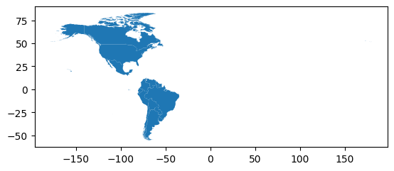

```python
# then

regions = ['CENTRAL AMERICA AND THE CARIBBEAN	', 'SOUTH AMERICA', 'NORTH AMERICA']

selected = theMapAndData[
    theMapAndData.region.isin(regions)
]

selected.plot()
```

### Preprocessing: aggregating

This is a DOT UNIT proposal:

```python
justDots=selected.copy()
dot_value = 100000
justDots['num_dots'] = (justDots['mobiles'] / dot_value).astype(int)
```

### Preprocessing: distributing dots

And here, we get a location for the dots:

```python
# 2. Generate the random dot locations using .sample_points()
justDots = justDots.sample_points(size=justDots['num_dots']).explode(index_parts=True)
```

You get this:

```python
justDots
```

|  |  | sampled_points |
| --- | --- | --- |
| 8 | 0 | POINT (-56.32407 -28.81159) |
|  | 1 | POINT (-60.56315 -29.16301) |
|  | 2 | POINT (-70.8807 -42.4343) |
|  | 3 | POINT (-64.54262 -36.42621) |
|  | 4 | POINT (-66.69565 -43.35795) |
| ... | ... | ... |
| 162 | 183 | POINT (-65.93725 2.55347) |
|  | 184 | POINT (-63.87187 7.02099) |
|  | 185 | POINT (-70.90344 9.48622) |
|  | 186 | POINT (-62.58815 4.33872) |
|  | 187 | POINT (-70.37291 10.83401) |

10577 rows × 1 columns

**dtype:** geometry

```python
# what is it?
type(justDots)
```

```
geopandas.geoseries.GeoSeries
def __init__(data=None, index=None, crs: Any | None=None, **kwargs)
```

[output not shown]

[output cut: 17 more lines]

[output not shown]

### Preprocessing: building GDF from GS

Notice the multi index (MI), one for a country and for a dot. As we are planing to send these points to R, we avoid MI:

```python
justDots.reset_index(drop=True, inplace=True)
selected_dots=gpd.GeoDataFrame(geometry=justDots)
selected_dots
```

|  | geometry |
| --- | --- |
| 0 | POINT (-56.32407 -28.81159) |
| 1 | POINT (-60.56315 -29.16301) |
| 2 | POINT (-70.8807 -42.4343) |
| 3 | POINT (-64.54262 -36.42621) |
| 4 | POINT (-66.69565 -43.35795) |
| ... | ... |
| 10572 | POINT (-65.93725 2.55347) |
| 10573 | POINT (-63.87187 7.02099) |
| 10574 | POINT (-70.90344 9.48622) |
| 10575 | POINT (-62.58815 4.33872) |
| 10576 | POINT (-70.37291 10.83401) |

10577 rows × 1 columns

Now you have a GDF:

```python
selected_dots.info()
```

```
<class 'geopandas.geodataframe.GeoDataFrame'>
RangeIndex: 10577 entries, 0 to 10576
Data columns (total 1 columns):
 #   Column    Non-Null Count  Dtype
---  ------    --------------  -----
 0   geometry  10577 non-null  geometry
dtypes: geometry(1)
memory usage: 82.8 KB
```

Juts plot the polygons as the base, and the points as the layer on top!

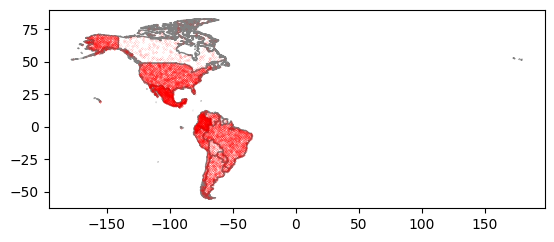

```python
base=selected.plot(facecolor="white",#color of polygon fill
               edgecolor='grey') #color of border
selected_dots.plot(markersize=0.005, color='red',ax=base)
```

It is generally recommended that DDMs use an **equal-area projection**, which benefits density and limits area distortion.

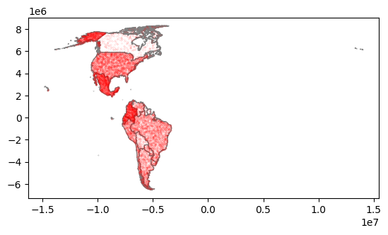

```python
base=selected.to_crs(8857).plot(facecolor="white",
                              edgecolor='grey')
selected_dots.to_crs(8857).plot(markersize=0.005, color='red',ax=base)
```

Let's keep the continent countries with that crs:

```python
selected_8857=selected.to_crs(8857)
selected_dots_8857=selected_dots.to_crs(8857)
```

# Thematics: the PSM (Proportional Symbol Map)

### Preprocessing: GDF of centroids

1. A location for a symbol, generally the polygon centroid.

```python
selected_8857_centroids = selected_8857.copy()

# selected_8857_centroids will have a new geometry:
selected_8857_centroids['geometry'] = selected_8857_centroids['geometry'].centroid
```

```python
selected_8857_centroids['size'] = selected_8857_centroids['mobiles'].apply(lambda x: x**0.5/100)

## or
# import numpy as np
# selected_8857_centroids['size'] = selected_8857_centroids['mobiles'].apply(lambda x: np.log10(x))
```

We got the basics, then:

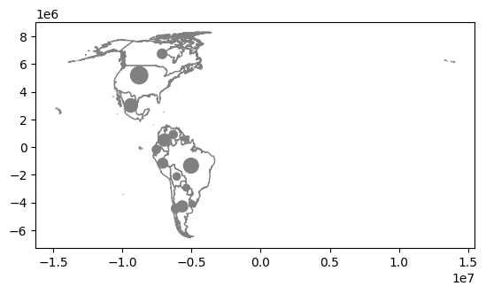

```python
base=selected_8857.plot(facecolor="white",
                      edgecolor='grey')
# Plot the centroids on top
selected_8857_centroids.plot(
    ax=base,
    markersize=selected_8857_centroids['size'],
    color='grey'
)
```

```python
# replace the points
selected_8857_centroids["geometry"]=selected_8857.representative_point()
```

### Preprocessing: Computing new columns

PPMs are not thematic maps to see precise values, but to reveal clear differences on the variable distribution used. As, human eyes are very limited to detect area differences, we may need to use some other tactics to help uncover some patterns.

For example, let's confirm if we have outliers:

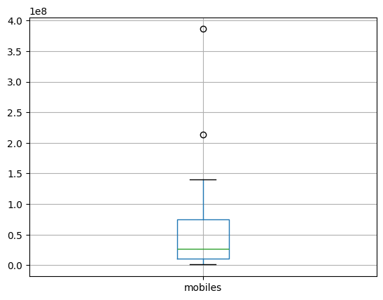

```python
boxplotInfo=selected_8857_centroids.boxplot(column='mobiles',return_type="dict")
```

The object **boxplotInfo** showed the boxplot, and we confirm there are outliers. We can recover them like this:

```python
outliers=boxplotInfo['fliers'][0].get_ydata()
## see
outliers
```

```
array([213000000, 386000000], dtype=object)
```

Then, these are the outlying countries:

```python
selected_8857_centroids[selected_8857_centroids.mobiles.isin(outliers)]
```

|  | Country | geometry | iso2 | iso3 | region | fragility | co2 | sq_km | num_airports | population | mobiles | size |
| --- | --- | --- | --- | --- | --- | --- | --- | --- | --- | --- | --- | --- |
| 23 | BRAZIL | POINT (-4700709.502 -1764170.762) | BR | BRA | SOUTH AMERICA | 71.8 | 456670000 | 8515770 | 5297 | 220051512 | 213000000 | 145.945195 |
| 158 | UNITED STATES | POINT (-8568177.661 4547618.41) | US | USA | NORTH AMERICA | 38.0 | 5144361000 | 9833517 | 16116 | 341963408 | 386000000 | 196.468827 |

Knowing this information, we can create a column as outlier flag:

```python
selected_8857_centroids['mobiles_outlier']=selected_8857_centroids.mobiles.isin(outliers)*1

## see
selected_8857_centroids
```

|  | Country | geometry | iso2 | iso3 | region | fragility | co2 | sq_km | num_airports | population | mobiles | size | mobiles_outlier |
| --- | --- | --- | --- | --- | --- | --- | --- | --- | --- | --- | --- | --- | --- |
| 8 | ARGENTINA | POINT (-5553772.712 -4493827.822) | AR | ARG | SOUTH AMERICA | 46.0 | 193205000 | 2780400 | 764 | 46994384 | 62700000 | 79.183332 | 0 |
| 19 | BOLIVIA | POINT (-6065512.507 -2073238.575) | BO | BOL | SOUTH AMERICA | 72.9 | 17786000 | 1098581 | 201 | 12311974 | 12000000 | 34.641016 | 0 |
| 23 | BRAZIL | POINT (-4700709.502 -1764170.762) | BR | BRA | SOUTH AMERICA | 71.8 | 456670000 | 8515770 | 5297 | 220051512 | 213000000 | 145.945195 | 1 |
| 28 | CANADA | POINT (-8057335.615 6460418.072) | CA | CAN | NORTH AMERICA | 20.0 | 612084000 | 9984670 | 1459 | 38794813 | 36500000 | 60.415230 | 0 |
| 35 | CHILE | POINT (-6234313.161 -4304799.911) | CL | CHL | SOUTH AMERICA | 38.9 | 88333000 | 756102 | 379 | 18664652 | 26700000 | 51.672043 | 0 |
| 38 | COLOMBIA | POINT (-6936232.356 525486.665) | CO | COL | SOUTH AMERICA | 75.7 | 81007000 | 1138910 | 661 | 49588357 | 87400000 | 93.487967 | 0 |
| 48 | ECUADOR | POINT (-7496744.998 -227636.718) | EC | ECU | SOUTH AMERICA | 71.2 | 36051000 | 283561 | 317 | 18309984 | 18200000 | 42.661458 | 0 |
| 68 | GUYANA | POINT (-5636237.099 628135.992) | GY | GUY | SOUTH AMERICA | 68.2 | 2743000 | 214969 | 55 | 794099 | 856000 | 9.252027 | 0 |
| 109 | MEXICO | POINT (-9402396.302 2972427.316) | MX | MEX | NORTH AMERICA | 69.7 | 463739000 | 1964375 | 1580 | 130739927 | 140000000 | 118.321596 | 0 |
| 117 | SURINAME | POINT (-5370305.407 503625.945) | SR | SUR | SOUTH AMERICA | 61.9 | 2372000 | 163820 | 55 | 646758 | 989000 | 9.944848 | 0 |
| 120 | PARAGUAY | POINT (-5383797.6 -2964049.838) | PY | PRY | SOUTH AMERICA | 67.0 | 7896000 | 406752 | 83 | 7522549 | 8670000 | 29.444864 | 0 |
| 121 | PERU | POINT (-7214274.314 -1170745.732) | PE | PER | SOUTH AMERICA | 68.2 | 54996000 | 1285216 | 174 | 32600249 | 41300000 | 64.265076 | 0 |
| 158 | UNITED STATES | POINT (-8568177.661 4547618.41) | US | USA | NORTH AMERICA | 38.0 | 5144361000 | 9833517 | 16116 | 341963408 | 386000000 | 196.468827 | 1 |
| 160 | URUGUAY | POINT (-4944550.554 -4064051.998) | UY | URY | SOUTH AMERICA | 34.0 | 6450000 | 176215 | 65 | 3425330 | 4800000 | 21.908902 | 0 |
| 162 | VENEZUELA | POINT (-6245177.294 816095.879) | VE | VEN | SOUTH AMERICA | 90.0 | 76730000 | 912050 | 509 | 31250306 | 18800000 | 43.358967 | 0 |

We can use that like this:

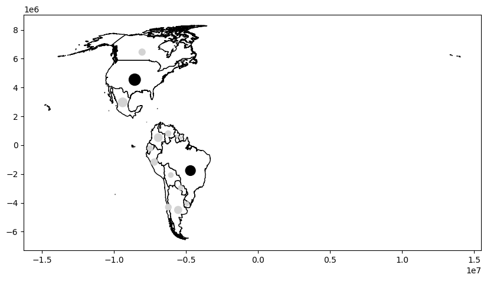

```python
base = selected_8857.plot(color='white', edgecolor='black', figsize=(10,10))

# Define your color map
mapcolor = {1: 'black', 0: 'lightgrey'}

# Plot the centroids on top
selected_8857_centroids.plot(
    ax=base,
    markersize=selected_8857_centroids['size'],
    color=selected_8857_centroids['mobiles_outlier'].map(mapcolor)
)
```

Here, we do a good job for outliers, but it is difficult to interprete the other ones. We could use some redundancy, but more work is needed:

1. Create two maps of centroids:

```python
# Create explicit copies of the DataFrames
selected_8857_centroids_out = selected_8857_centroids[selected_8857_centroids.mobiles_outlier==1].copy()
selected_8857_centroids_no_out = selected_8857_centroids[selected_8857_centroids.mobiles_outlier==0].copy()
```

2. Compute sizes in each:

```python
selected_8857_centroids_out['size'] = selected_8857_centroids_out['mobiles'].apply(lambda x: x**0.5 / 50)
selected_8857_centroids_no_out['size'] = selected_8857_centroids_no_out['mobiles'].apply(lambda x: x**0.5 / 50)
```

Now, plot the three layers, using some color gradient for the non-outliers:

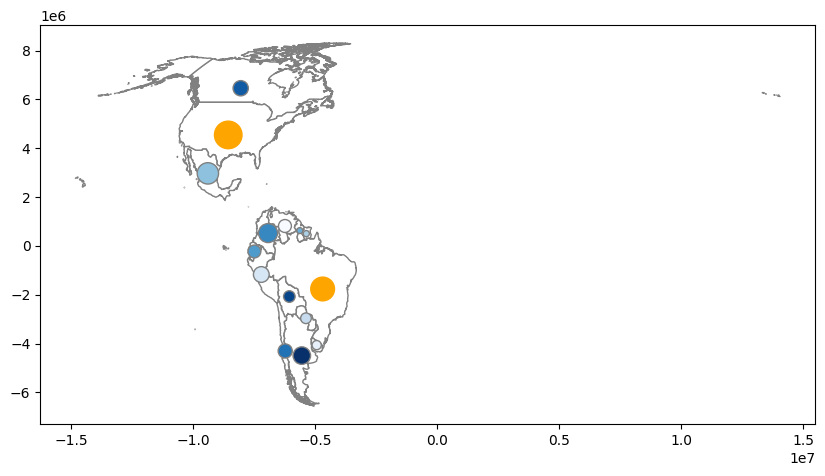

```python
base=selected_8857.plot(color='white', edgecolor='grey',figsize=(10,10))

selected_8857_centroids_no_out.plot(
    ax=base,
    markersize=selected_8857_centroids_no_out['size'],
    edgecolor='grey',
    c=selected_8857_centroids_no_out['size'],
    cmap='Blues_r'
)
selected_8857_centroids_out.plot(
    ax=base,
    markersize=selected_8857_centroids_out['size'],
    color='orange'
)
```

# Thematics: Choropleths

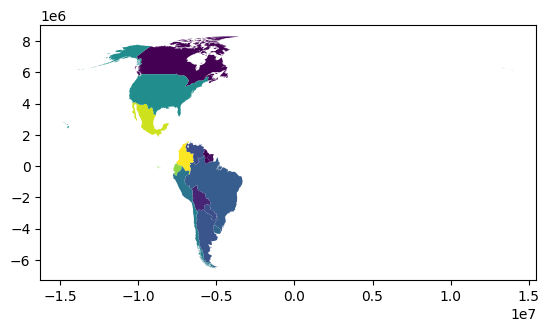

```python
selected_8857.plot(selected_8857.mobiles/selected_8857.sq_km)
```

Choropleths are great to represent normalized indicators such as:

- Densities
- Ratios
- Rates
- Averages

### Preprocessing: Discretizing

Now, we want to cut the variable. Run the next code to make sure you have tose packages:

```python
## do you have these installed?
! pip show numba mapclassify numpy
```

[output not shown]

[output cut: 948 more lines]

[output not shown]

We will discretize this:

```python
selected_8857['mobiles_density']=selected_8857.population/selected_8857.sq_km
```

Let's explore the bining algorithms:

```python
import mapclassify
import numpy as np

np.random.seed(12345) # so we all get the same results!

# let's try 5 intervals
K=5
theVar=selected_8857['mobiles_density']
# same interval width, easy interpretation
ei5 = mapclassify.EqualInterval(theVar, k=K)
# same interval width based on standard deviation, easy - but not as the previous one, poor when high skewness
msd = mapclassify.StdMean(theVar)
# interval width varies, counts per interval are close, not easy to grasp, repeated values complicate cuts
q5=mapclassify.Quantiles(theVar,k=K)

# based on similarity, good for multimodal data
mb5 = mapclassify.MaximumBreaks(theVar, k=K)
# based on similarity, good for skewed data
ht = mapclassify.HeadTailBreaks(theVar) # no K needed
# based on similarity, optimizer
fj5 = mapclassify.FisherJenks(theVar, k=K)
# based on similarity, optimizer
jc5 = mapclassify.JenksCaspall(theVar, k=K)
# based on similarity, optimizer
mp5 = mapclassify.MaxP(theVar, k=K)
```

How can we select the right classification? Let me use the the Absolute deviation around class median (ADCM) to make the comparisson:

```python
class5 = ei5,msd, q5,mb5,  ht, fj5, jc5, mp5
# Collect ADCM for each classifier
fits = np.array([ c.adcm for c in class5])
# Convert ADCM scores to a DataFrame
adcms = pd.DataFrame(fits)
# Add classifier names
adcms['classifier'] = [c.name for c in class5]
# Add column names to the ADCM
adcms.columns = ['ADCM', 'Classifier']
```

Now, plot the **adcms**:

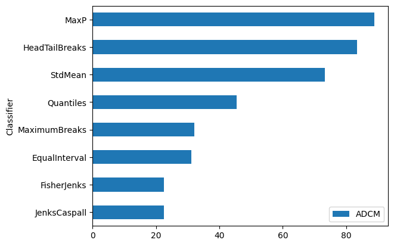

```python
adcms.sort_values('ADCM').plot.barh(x='Classifier')
```

Let's save the best strategy:

```python
selected_8857['mobiles_density_FJ5'] = fj5.yb
```

```python
# there you are
selected_8857[['mobiles_density','mobiles_density_FJ5']].head(20)
```

|  | mobiles_density | mobiles_density_FJ5 |
| --- | --- | --- |
| 8 | 16.902023 | 1 |
| 19 | 11.207161 | 1 |
| 23 | 25.840472 | 2 |
| 28 | 3.885438 | 0 |
| 35 | 24.685363 | 2 |
| 38 | 43.540189 | 3 |
| 48 | 64.571588 | 4 |
| 68 | 3.694016 | 0 |
| 109 | 66.555483 | 4 |
| 117 | 3.947979 | 0 |
| 120 | 18.494191 | 1 |
| 121 | 25.365580 | 2 |
| 158 | 34.775290 | 3 |
| 160 | 19.438357 | 1 |
| 162 | 34.263808 | 3 |

We could create a copy of the bins to add labels:

```python
# renaming
newLabelsForLevels={0:"0_VeryLow", 1:"1_Low", 2:"2_Middle", 3:"3_High", 4:"4_VeryHigh"}

selected_8857['mobiles_density_FJ5_cat']=selected_8857.loc[:,'mobiles_density_FJ5'].replace(newLabelsForLevels)

# we have
selected_8857[['mobiles_density','mobiles_density_FJ5','mobiles_density_FJ5_cat']].head(20)
```

|  | mobiles_density | mobiles_density_FJ5 | mobiles_density_FJ5_cat |
| --- | --- | --- | --- |
| 8 | 16.902023 | 1 | 1_Low |
| 19 | 11.207161 | 1 | 1_Low |
| 23 | 25.840472 | 2 | 2_Middle |
| 28 | 3.885438 | 0 | 0_VeryLow |
| 35 | 24.685363 | 2 | 2_Middle |
| 38 | 43.540189 | 3 | 3_High |
| 48 | 64.571588 | 4 | 4_VeryHigh |
| 68 | 3.694016 | 0 | 0_VeryLow |
| 109 | 66.555483 | 4 | 4_VeryHigh |
| 117 | 3.947979 | 0 | 0_VeryLow |
| 120 | 18.494191 | 1 | 1_Low |
| 121 | 25.365580 | 2 | 2_Middle |
| 158 | 34.775290 | 3 | 3_High |
| 160 | 19.438357 | 1 | 1_Low |
| 162 | 34.263808 | 3 | 3_High |

We are ready for a discrete choropleth:

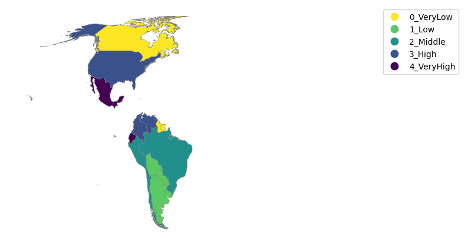

```python
import matplotlib.pyplot as plt

f, ax = plt.subplots(1, figsize=(10, 10))
selected_8857.plot(column='mobiles_density_FJ5_cat', # variable to plot
                 cmap='viridis_r', # set of colors
                 categorical=True, # can be interpreted as category
                 edgecolor='grey', # border color
                 linewidth=0.3, # width of border
                 legend=True, # need a legend?
                 ax=ax
       )

ax.set_axis_off()
```